# Beverlyn Tucker HW5 Text Classifier Evaluation and Human Annotation

## Introduction

Today's generation abundance of available data has encouraged many existing statistical methods to apply predictive and prescriptive forecasting. Classification algorithms often require train data to include target labels, often time-consuming to construct. However, crowdsourcing tools like Amazon Mechanical Turk (MTurk) allow the individual(s) to upload their dataset, then pay another to label the rows of the data for a small price. Enables data scientists to focus on essential data acquisition and more on analysis and reporting.

While MTurk has been around since 2005, many research organizations have either not heard of the platform, or not considered utilizing the tool. Requesters can hire multiple workers within the platform or restrict the type of workers based on satisfied credentials. This allows requesters to restrict who can work on their given dataset selectively. Furthermore, the idea of a "small price" is relative to the size of the dataset. However, careful inferencing could potentially reduce the scope and size.

## Analysis

While MTurk provides many great functionalities, a cross-sectional analysis was made between each worker, against the overall ground truth. Five MTurk workers will be hired, at dollar 0.02 per task, to label 201 rows within a given dataset into defined sentiments (positive, negative, and neutral). This equates roughly $20.10. Then Utilize Cohen Kappa score was conducted for each of the following intereviewers

## DATA PREPATION

Data come from HW1 sent to AMT and Included myself to the mix to have a feel what the reviewers feels and see.

```python
import pandas as pd
import numpy as np
from sklearn.metrics import cohen_kappa_score
import matplotlib.pyplot as plt
import seaborn as sns
```

```python
df = pd.read_csv('C:\\Users\\bevst\\Downloads\\IST736\\WK5\\AI_Tweets_AMZ_T.csv',encoding='cp1252')
```

```python
df.head()
```

|  | d | label | user | timestamp | text | reviewer1 | reviewer2 | reviewer3 | reviewer4 | reviewer5 | Myself |
| --- | --- | --- | --- | --- | --- | --- | --- | --- | --- | --- | --- |
| 0 | 1 | 0 | _ItsJustChris | 12/26/2011 22:44 | Artificial Intelligence Is Going To Be The End... | neg | neg | neg | neg | neg | neg |
| 1 | 47 | 0 | AnonTechOps | 1/14/2019 23:20 | The Weaponization Of Artificial Intelligence #... | neg | neg | neg | neg | neg | neg |
| 2 | 53 | 0 | Arnold_Haine | 1/14/2019 23:25 | The Weaponization Of Artificial Intelligence #... | neg | neg | neg | neg | neg | neg |
| 3 | 86 | 0 | BitHack3r | 5/6/2011 18:53 | @TheChameleon84 wow. I hate Artificial Intelli... | neg | neu | neu | neg | neg | neg |
| 4 | 103 | 0 | brittneyinc | 7/19/2014 21:50 | this artificial intelligence performance kind ... | neg | neg | neg | neg | neu | neg |

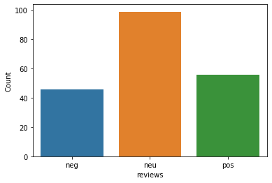

```python
sns.countplot('reviewer1', data=df)
_ = plt.xlabel('reviews')
_ = plt.ylabel('Count')
plt.show()
```

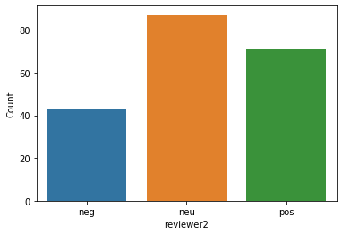

```python
sns.countplot('reviewer2', data=df)
_ = plt.xlabel('reviewer2')
_ = plt.ylabel('Count')
plt.show()
```

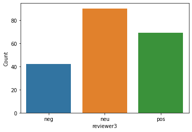

```python
sns.countplot('reviewer3', data=df)
_ = plt.xlabel('reviewer3')
_ = plt.ylabel('Count')
plt.show()
```

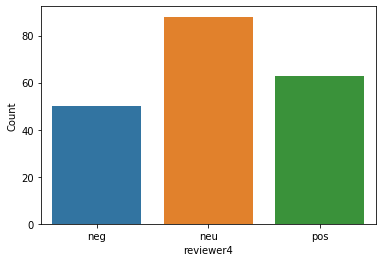

```python
sns.countplot('reviewer4', data=df)
_ = plt.xlabel('reviewer4')
_ = plt.ylabel('Count')
plt.show()
```

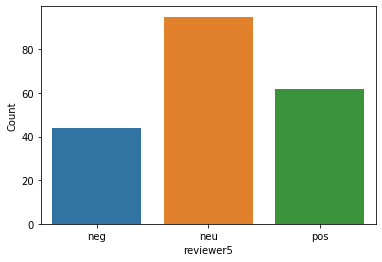

```python
sns.countplot('reviewer5', data=df)
_ = plt.xlabel('reviewer5')
_ = plt.ylabel('Count')
plt.show()
```

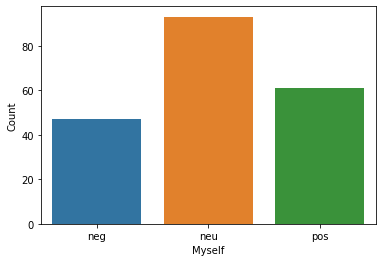

```python
sns.countplot('Myself', data=df)
_ = plt.xlabel('Myself')
_ = plt.ylabel('Count')
plt.show()
```

```python
# Select the five reviewer columns.
cols = ['reviewer1', 'reviewer2', 'reviewer3', 'reviewer4', 'reviewer5','Myself']
reviewers = df[cols]

# Initiate an empty array and count sentiment for each reviewer.
reviews = []

for i in reviewers[cols]:
    sentiment = reviewers.groupby(i)[i].count()
    reviews.append(sentiment)

# Convert results to data frame; pass cols to index for easier identification; rename columns to neg, neu, and pos.
results = pd.DataFrame(np.array(reviews))
results.set_index(pd.Index(cols), inplace=True)
results.columns = ['neg', 'neu', 'pos']
print(results)
```

```
           neg  neu  pos
reviewer1   46   99   56
reviewer2   43   87   71
reviewer3   42   90   69
reviewer4   50   88   63
reviewer5   44   95   62
Myself      47   93   61
```

## Create empty array for Kappa Result

perform loop to view each reviewers to compare each results

```python
#  empty array to store Cohen-Kappa test results.
Kappa_results = []

# Loop over each reviewer and calculate the Cohen-Kappa score against each reviewer

for i in reviewers[cols]:
    reviewer_compare = reviewers
    for j in reviewer_compare:
        result = cohen_kappa_score(reviewers[i], reviewer_compare[j])
        Kappa_results.append(result)

# Build a pandas DataFrame with the results amd index the name to identify the reviewers.
Kappa_results = pd.DataFrame(np.array(Kappa_results).reshape(-1, 6))
Kappa_results.set_index(pd.Index(cols), inplace=True)
Kappa_results.columns = cols

Kappa_results = Kappa_results.mask(np.triu(np.ones(Kappa_results.shape, dtype=np.bool_)))
Kappa_results
```

|  | reviewer1 | reviewer2 | reviewer3 | reviewer4 | reviewer5 | Myself |
| --- | --- | --- | --- | --- | --- | --- |
| reviewer1 | NaN | NaN | NaN | NaN | NaN | NaN |
| reviewer2 | 0.618758 | NaN | NaN | NaN | NaN | NaN |
| reviewer3 | 0.460245 | 0.471584 | NaN | NaN | NaN | NaN |
| reviewer4 | 0.463710 | 0.445984 | 0.405508 | NaN | NaN | NaN |
| reviewer5 | 0.558588 | 0.595542 | 0.437434 | 0.356738 | NaN | NaN |
| Myself | 0.560587 | 0.597350 | 0.471216 | 0.667883 | 0.445054 | NaN |

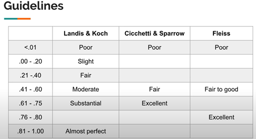

## Conclusion

Amazon Mechanical Turk (MTurk) allow research studies to utilize unlabeled data by crowdsourcing the labeling responsibilities. During this process, any number of workers can be selected for hire. Prioritization can be established by incentivizing the rate of payment per task. Furthermore, overall scores can be improved by incorporating multiple workers and averaging the total scores. Additional benefits of MTurk include selectively choosing workers by any number of criteria, including geography, age, education, or professional status.

Though results across reviewers are moderate, it could be beneficial to have a larger Datasets. And utilize a platform like an amazon mechanical Turk. Data scientists and research groups focus on deriving research findings.

Overall, the MTurk concept is hugely beneficial. After knowing how much time, I have spent tagging each sentence. Utilizing a crowdsourcing platform is not new and currently being used by large and small organizations alike. While data labeling results are generally more accurate when performed by an internal research group, consideration should be based on optimal time management.